# Practical Machine Learning Course Project

Tze Yen Wong

09/10/2020

## Overview

This report looks at devices such as Jawbone Up, Nike FuelBand, and Fitbit to predict the manner in which user did the exercise. A group of enthusiasts take measurements about themselves regularly to improve their health, to find patterns in their behaviour and to quantify how much of a particular activity they do. In this report, we use data from accelerometers on the belt, forearm, arm, and dumbell of 6 participants which they perform barbell lifts correctly and incorrectly in 5 different ways. To predict, the “classe” variable in the training set should be use along with other variables.

## Dataset

The data from the report come from:  
http://web.archive.org/web/20161224072740/http:/groupware.les.inf.puc-rio.br/har.

The training data:  
https://d396qusza40orc.cloudfront.net/predmachlearn/pml-training.csv

The test data:  
https://d396qusza40orc.cloudfront.net/predmachlearn/pml-testing.csv

## Loading packages

Loading packages needed for the analysis:

```r
library(caret)
library(rattle)
library(rpart)
set.seed(807)
```

## Loading and Cleaning Data

Loading data:

```r
train_data <- read.csv('https://d396qusza40orc.cloudfront.net/predmachlearn/pml-training.csv')
validation <- read.csv('https://d396qusza40orc.cloudfront.net/predmachlearn/pml-testing.csv')
```

We partition the training data into 2 to create training (70%) and testing (30%) part.

```r
inTrain <- createDataPartition(train_data$classe, p=0.7, list=FALSE)
training <- train_data[inTrain,]
testing <- train_data[-inTrain,]
dim(training)
```

```
## [1] 13737   160
```

```r
dim(testing)
```

```
## [1] 5885  160
```

Since the data may contain a lot of NA values and variables, we need to remove them before running analysis.

```r
# remove nearly zero variance variables
nearzero <- nearZeroVar(training)
training <- training[, -nearzero]
testing <- testing[,-nearzero]
dim(training)
```

```
## [1] 13737   105
```

```r
dim(testing)
```

```
## [1] 5885  105
```

```r
# remove mostly NA variables
var_NA <- sapply(training, function(x) mean(is.na(x)))
training <- training[, var_NA==FALSE]
testing <- testing[, var_NA==FALSE]
dim(training)
```

```
## [1] 13737    59
```

```r
dim(testing)
```

```
## [1] 5885   59
```

```r
# remove identification variables
training <- training[, -(1:5)]
testing <- testing[, -(1:5)]
dim(training)
```

```
## [1] 13737    54
```

```r
dim(testing)
```

```
## [1] 5885   54
```

## Prediction Model Building

For this project, we use 3 different model algorithm to predict and see which gives the highest accuracy. These include:  
1. Decision tree  
2. Generalized boosted model  
3. Random Forest

### 1. Decision tree

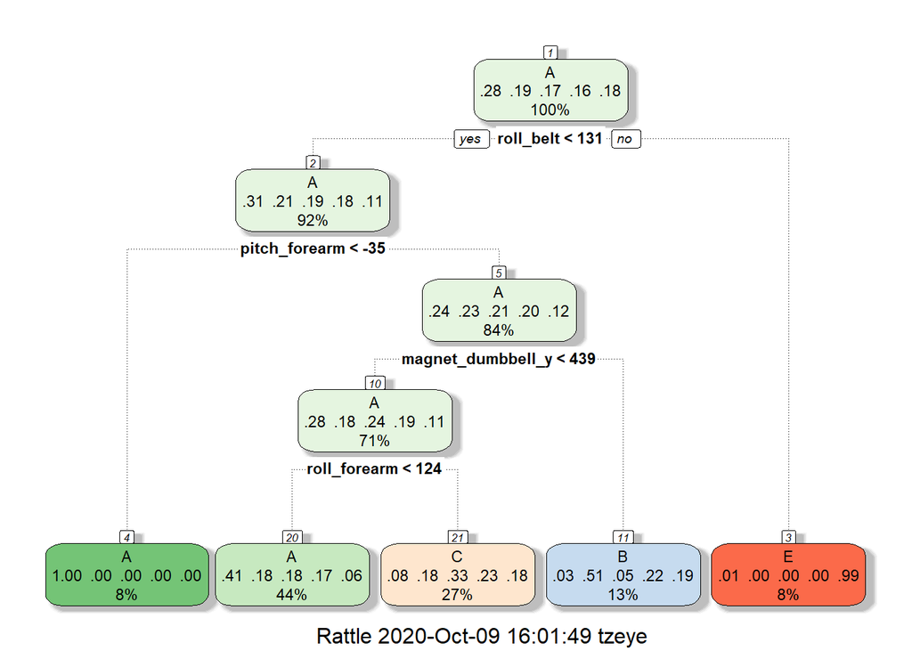

```r
# Decision tree model fit
modFit_DT <- train(classe ~., method="rpart", data=training)
fancyRpartPlot(modFit_DT$finalModel)
```

### 2. Generalized boosted model

```r
# GBM model fit
control <- trainControl(method="repeatedcv", number=5, repeats=1)
modFit_GBM <- train(classe ~., method="gbm",data=training, trControl=control, verbose=FALSE)
modFit_GBM$finalModel
```

```
## A gradient boosted model with multinomial loss function.
## 150 iterations were performed.
## There were 53 predictors of which 53 had non-zero influence.
```

### 3. Random Forest

```r
# Random forest model fit
modFit_RF <- train(classe ~., method="rf",data=training, trControl=trainControl(method="cv", 5), ntree=100)
modFit_RF$finalModel
```

```
##
## Call:
##  randomForest(x = x, y = y, ntree = 100, mtry = param$mtry)
##                Type of random forest: classification
##                      Number of trees: 100
## No. of variables tried at each split: 27
##
##         OOB estimate of  error rate: 0.29%
## Confusion matrix:
##      A    B    C    D    E  class.error
## A 3905    1    0    0    0 0.0002560164
## B    5 2645    8    0    0 0.0048908954
## C    0    4 2392    0    0 0.0016694491
## D    0    0    9 2242    1 0.0044404973
## E    0    1    0   11 2513 0.0047524752
```

## Model Assessment (Sample error)

```r
# Prediction on test data (Decision Tree)
predict_DT <- predict(modFit_DT, newdata=testing)
confm_DT <- confusionMatrix(factor(predict_DT), factor(testing$classe))
confm_DT
```

```
## Confusion Matrix and Statistics
##
##           Reference
## Prediction    A    B    C    D    E
##          A 1521  473  477  423  165
##          B   26  396   28  179  155
##          C  122  270  521  362  285
##          D    0    0    0    0    0
##          E    5    0    0    0  477
##
## Overall Statistics
##
##                Accuracy : 0.4953
##                  95% CI : (0.4825, 0.5082)
##     No Information Rate : 0.2845
##     P-Value [Acc > NIR] : < 2.2e-16
##
##                   Kappa : 0.3404
##
##  Mcnemar's Test P-Value : NA
##
## Statistics by Class:
##
##                      Class: A Class: B Class: C Class: D Class: E
## Sensitivity            0.9086  0.34767  0.50780   0.0000  0.44085
## Specificity            0.6348  0.91825  0.78617   1.0000  0.99896
## Pos Pred Value         0.4972  0.50510  0.33397      NaN  0.98963
## Neg Pred Value         0.9459  0.85434  0.88324   0.8362  0.88803
## Prevalence             0.2845  0.19354  0.17434   0.1638  0.18386
## Detection Rate         0.2585  0.06729  0.08853   0.0000  0.08105
## Detection Prevalence   0.5198  0.13322  0.26508   0.0000  0.08190
## Balanced Accuracy      0.7717  0.63296  0.64698   0.5000  0.71990
```

```r
# Prediction on test data (GBM)
predict_GBM <- predict(modFit_GBM, newdata=testing)
confm_GBM <- confusionMatrix(factor(predict_GBM), factor(testing$classe))
confm_GBM
```

```
## Confusion Matrix and Statistics
##
##           Reference
## Prediction    A    B    C    D    E
##          A 1664    5    0    0    0
##          B   10 1120    7    6    3
##          C    0   12 1015   12    2
##          D    0    2    4  946   14
##          E    0    0    0    0 1063
##
## Overall Statistics
##
##                Accuracy : 0.9869
##                  95% CI : (0.9837, 0.9897)
##     No Information Rate : 0.2845
##     P-Value [Acc > NIR] : < 2.2e-16
##
##                   Kappa : 0.9835
##
##  Mcnemar's Test P-Value : NA
##
## Statistics by Class:
##
##                      Class: A Class: B Class: C Class: D Class: E
## Sensitivity            0.9940   0.9833   0.9893   0.9813   0.9824
## Specificity            0.9988   0.9945   0.9946   0.9959   1.0000
## Pos Pred Value         0.9970   0.9773   0.9750   0.9793   1.0000
## Neg Pred Value         0.9976   0.9960   0.9977   0.9963   0.9961
## Prevalence             0.2845   0.1935   0.1743   0.1638   0.1839
## Detection Rate         0.2828   0.1903   0.1725   0.1607   0.1806
## Detection Prevalence   0.2836   0.1947   0.1769   0.1641   0.1806
## Balanced Accuracy      0.9964   0.9889   0.9920   0.9886   0.9912
```

```r
# Prediction on test data (Random Forest)
predict_RF <- predict(modFit_RF, newdata=testing)
confm_RF <- confusionMatrix(factor(predict_RF), factor(testing$classe))
confm_RF
```

```
## Confusion Matrix and Statistics
##
##           Reference
## Prediction    A    B    C    D    E
##          A 1673    2    0    0    0
##          B    0 1137    1    0    0
##          C    0    0 1025    4    0
##          D    0    0    0  960    2
##          E    1    0    0    0 1080
##
## Overall Statistics
##
##                Accuracy : 0.9983
##                  95% CI : (0.9969, 0.9992)
##     No Information Rate : 0.2845
##     P-Value [Acc > NIR] : < 2.2e-16
##
##                   Kappa : 0.9979
##
##  Mcnemar's Test P-Value : NA
##
## Statistics by Class:
##
##                      Class: A Class: B Class: C Class: D Class: E
## Sensitivity            0.9994   0.9982   0.9990   0.9959   0.9982
## Specificity            0.9995   0.9998   0.9992   0.9996   0.9998
## Pos Pred Value         0.9988   0.9991   0.9961   0.9979   0.9991
## Neg Pred Value         0.9998   0.9996   0.9998   0.9992   0.9996
## Prevalence             0.2845   0.1935   0.1743   0.1638   0.1839
## Detection Rate         0.2843   0.1932   0.1742   0.1631   0.1835
## Detection Prevalence   0.2846   0.1934   0.1749   0.1635   0.1837
## Balanced Accuracy      0.9995   0.9990   0.9991   0.9977   0.9990
```

## Applying the Selected Model to the Test Data

Therefore, the random forest model will be applied to predict the 20 quiz results.

```r
predict_validation <- predict(modFit_RF, newdata=validation)
predict_validation
```

```
##  [1] B A B A A E D B A A B C B A E E A B B B
## Levels: A B C D E
```